# Task 1: Palmetto Binary Logistic Regression (PELEGRI)

Patrick Pelegri-O’Day

1/30/2022

```r
knitr::opts_chunk$set(echo = TRUE, message = FALSE, warning = FALSE)

library(tidyverse)
library(GGally)
library(here)
library(cowplot)
library(broom)
library(jtools)
library(caret)
library(kableExtra)
```

A. Overview B. 3 finalized plots exploring differences in variables for the two species C. Run binary logistic regression - Then perform cross validation - Then check AICc D. Train selected model on entire dataset and show results in a table E. Show prediction accuracy in a table

### Overview

This report uses binary logistic regression to test the feasibility of using variables plant height, canopy length, canopy width, and number of green leaves to classify whether a palmetto is species Serenoa repens or Sabal etonia. The dataset is drawn from observations of two dominant palmetto species of south-central Florida from 1981 - 2017.

**Data source:** Abrahamson, W.G. 2019. Survival, growth and biomass estimates of two dominant palmetto species of south-central Florida from 1981 - 2017, ongoing at 5-year intervals ver 1. Environmental Data Initiative. https://doi.org/10.6073/pasta/f2f96ec76fbbd4b9db431c79a770c4d5

### Data exploration

A subset of the data is retained for analysis. The variables considered include species of palmetto, plant height, canopy length, canopy width, and green leaves.

```r
# Read in the data
palmetto_raw <- read_csv(here("data", "palmetto.csv"))

# Take subset for exploration and analysis. Rename species variables by their latin name and convert to factor
palmetto <- palmetto_raw %>%
  select(species, height, length, width, green_lvs) %>%
  mutate(species = case_when(
    species == 1 ~ "Sabal etonia",
    species == 2 ~ "Serenoa repens"
  )) %>%
  mutate(species = as.factor(species)) %>%  # Sabal etonia is 1st, Serenoa repens is 2nd
  drop_na()
```

Below, differences in plant height, canopy length, canopy width, and green leaves are explored for the two species, Serenoa repens and Sabal etonia.

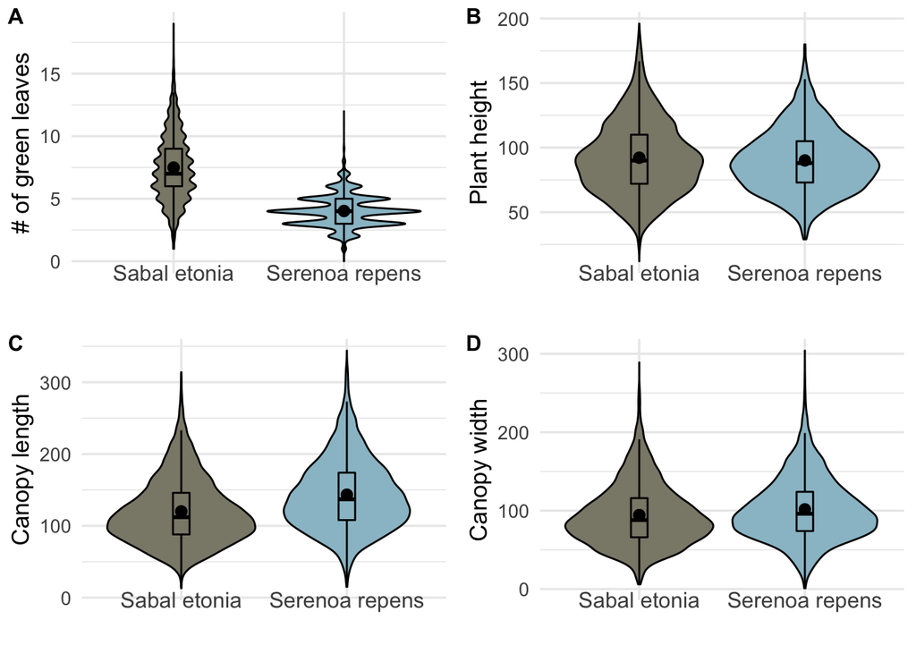

```r
# Explore differences between the two species

# The code below explores the four variables of interest with one plot for each variable. The code for each plot is the same except for the variable name.
explore1 <-ggplot(data = palmetto, aes(x = species, y = green_lvs, fill = species)) +
  geom_violin(scale = "count", color = "black") + # mirrored density plot
geom_boxplot(color = "black", fill = NA, width = 0.1, outlier.color = NA) + # add  median and quartiles
  stat_summary(fun=mean, # add the mean to the figure
               geom="point",
               shape=20,
               size=4,
               color="black",
               fill="black") +
  scale_fill_manual(values = c("cornsilk4", "lightblue3")) +
  theme_minimal(13) + # change theme and font size
  theme(legend.position = "none",
        axis.text.x = element_text(vjust = 5, size = 12)) +
  labs(x = element_blank(), y = "# of green leaves")

explore2 <-ggplot(data = palmetto, aes(x = species, y = height, fill = species)) +
  geom_violin(scale = "count", color = "black") +
geom_boxplot(color = "black", fill = NA, width = 0.1, outlier.color = NA) +
  stat_summary(fun=mean,
               geom="point",
               shape=20,
               size=4,
               color="black",
               fill="black") +
  scale_fill_manual(values = c("cornsilk4", "lightblue3")) +
  theme_minimal(13) +
  theme(legend.position = "none",
        axis.text.x = element_text(vjust = 5, size = 12)) +
  labs(x = element_blank(), y = "Plant height")

explore3 <-ggplot(data = palmetto, aes(x = species, y = length, fill = species)) +
  geom_violin(scale = "count", color = "black") +
geom_boxplot(color = "black", fill = NA, width = 0.1, outlier.color = NA) +
  stat_summary(fun=mean,
               geom="point",
               shape=20,
               size=4,
               color="black",
               fill="black") +
  scale_fill_manual(values = c("cornsilk4", "lightblue3")) +
  theme_minimal(13) +
  theme(legend.position = "none",
        axis.text.x = element_text(vjust = 5, size = 12)) +
  labs(x = element_blank(), y = "Canopy length")


explore4 <-ggplot(data = palmetto, aes(x = species, y = width, fill = species)) +
  geom_violin(scale = "count", color = "black") +
geom_boxplot(color = "black", fill = NA, width = 0.1, outlier.color = NA) +
  stat_summary(fun=mean,
               geom="point",
               shape=20,
               size=4,
               color="black",
               fill="black") +
  scale_fill_manual(values = c("cornsilk4", "lightblue3")) +
  theme_minimal(13) +
  theme(legend.position = "none",
        axis.text.x = element_text(vjust = 5, size = 12)) +
  labs(x = element_blank(), y = "Canopy width")

plot_grid(explore1, explore2, explore3, explore4, labels = c('A', 'B', 'C', 'D'), label_size = 12, nrow = 2)
```

### Binary logistic regression

#### Create models

Two binary logistic regression models are created to predict palmetto species based on palmetto traits. One model contains all four variables of interest and is called **Model All**. The other model contains only canopy width, plant height, and number of green leaves and is called **Model Subset**.

```r
# Define two functions that will be the basis of two models
f_all <- species ~ green_lvs + width + height + length
f_subset <- species ~ green_lvs + width + height

# Define two binary logistic regression models based on the functions above
palmetto_blr_all <- glm(formula = f_all,
                    data = palmetto,
                    family = 'binomial')

palmetto_blr_subset <- glm(formula = f_subset,
                    data = palmetto,
                    family = 'binomial')
```

#### Compare models

Cross validation using 10 folds and 10 iterations is performed to compare the performance of the two models.

```r
set.seed(47)

# Define training method as cross validation, 10 folds, 10 repeats
tr_ctrl <- trainControl(method = 'repeatedcv', number = 10, repeats = 10)

# Train the two models
model_all <- train(f_all, data = palmetto,
                method = 'glm', family = 'binomial',
                trControl = tr_ctrl)

model_subset <- train(f_subset, data = palmetto,
                method = 'glm', family = 'binomial',
                trControl = tr_ctrl)
```

[output not shown]

```r
# Also compare AICc
palmetto_aic <- AICcmodavg::aictab(list(palmetto_blr_all, palmetto_blr_subset))

palmetto_aic # AIC results indicate that Model 1 is preferable since it is lower by 793 points
```

```
##
## Model selection based on AICc:
##
##      K    AICc Delta_AICc AICcWt Cum.Wt       LL
## Mod1 5 5194.57       0.00      1      1 -2592.28
## Mod2 4 5987.48     792.91      0      1 -2989.74
```

AICc results show that Model All (AICc of 5194.6) outperforms Model Subset (AICc of 5987.5) by approximately 792.9 points. This difference is very large - much larger than the significant difference threshold of 2 points. AICc confirms that Model All is preferable to Model Subset.

#### Present model results

```r
# Store tidy results of final model (Model All) for display in a table
palmetto_blr_final <- tidy(palmetto_blr_all) %>%
  mutate(p.value = case_when( # rename p-values for readability
    p.value <0.001 ~ "<0.001"
  )) %>%
  mutate(term = case_when(
         term == "(Intercept)" ~ "Intercept",
         term == "height" ~ "Height",
         term == "length" ~ "Length",
         term == "width" ~ "Width",
         term == "green_lvs" ~ "# of green leaves")) %>%
  select(-statistic)
```

##### **Table 1.** Coefficients for each variable in the final selected model, Model All.

```r
# Create table
kable(palmetto_blr_final,
      col.names = c("Term", "Coefficient", "Standard Error", "P Value")) %>%
  kable_minimal(full_width = FALSE)
```

| Term | Coefficient | Standard Error | P Value |
| --- | --- | --- | --- |
| Intercept | 3.2266851 | 0.1420708 | <0.001 |
| # of green leaves | -1.9084747 | 0.0388634 | <0.001 |
| Width | 0.0394434 | 0.0021000 | <0.001 |
| Height | -0.0292173 | 0.0023061 | <0.001 |
| Length | 0.0458233 | 0.0018661 | <0.001 |

#### Evaluate model predictions

This code evaluates how successfully Model All would classify a palmetto plant as the correct species, using a 50% cutoff. That is, if the model evaluates a likelihood of =>50% that the observation is Serenoa repens, then the model will predict that observation is Serenoa repens. Predictions are then compared to actual observations to determine the accuracy of the model’s predictions.

```r
# Create function for prediction accuracy
predict_accuracy_f <- function(x, y) {
  accurate <- ifelse(x == y, 1, 0)
  return(accurate)
}

# Create fitted outcomes for each model, create column predicted_species based on predictions, create column prediction_result that shows 1 for correct prediction and 0 for incorrect prediction
blr_all_predictions <- palmetto_blr_all %>%
  augment(type.predict = 'response') %>%
  mutate(predicted_species = case_when(
    .fitted >= 0.5 ~ "Serenoa repens", # Serenoa is our 1 value because it is factor 2
    .fitted < 0.5 ~ "Sabal etonia" # Sabal is our 0 value because it is factor 1
  )) %>%
  mutate(prediction_result = predict_accuracy_f(species, predicted_species))

# See what percentage of the time the model predicted correctly
blr_all_accuracy <- blr_all_predictions %>%
  group_by(species) %>%
  summarize(pred_accuracy_v = round(mean(prediction_result), 2))
```

##### **Table 2.** Summary of the percentage of accurate predictions from Model All for each palmetto species. The average accuracy of the model was* 92 *percent*

```r
# Return results in a table
kable(blr_all_accuracy,
      col.names = c("Species", "% correctly classified")) %>%
  kable_minimal(full_width = FALSE)
```

| Species | % correctly classified |
| --- | --- |
| Sabal etonia | 0.91 |
| Serenoa repens | 0.93 |